# Protest Domain Report: Local development

[figure not shown]

This dashboard summarizes deaths in the **Local development** protest domain in the Ultimate Consequences database. All deaths in the dataset are categorized into a general arena of conflict, each of which may involve multiple events and campaigns.

Overall, the database catalogs deaths in Bolivian political conflict during the democratic era, 10 October 1982 to the present. The map to the right shows these deaths broken down by municipality. Politically and administratively, the country is divided into 9 departments, 112 provinces, 340 municipalities and 1,384 cantons.

There have been 5 deadly events involving 6 confirmed deaths and a total of 6 listed deaths in the **Local development** domain of protest.

- Deaths in this domain comprise **1%** of all confirmed deaths.
- Local development ranks **14** out of 20 domains in the dataset.
- There were **4** killed by state security forces, and there were **0** state-affiliated victims.
- The average age of the deceased in this domain is **36.8** years. The youngest was **16 years** old and the oldest was **72 years** old.

The table below can be ordered by any of its variables and searched by the text variables as well as the year. At the bottom you can choose how many events to show, or page through the events. By default, events are ordered chronologically.

#### Histogram by Year

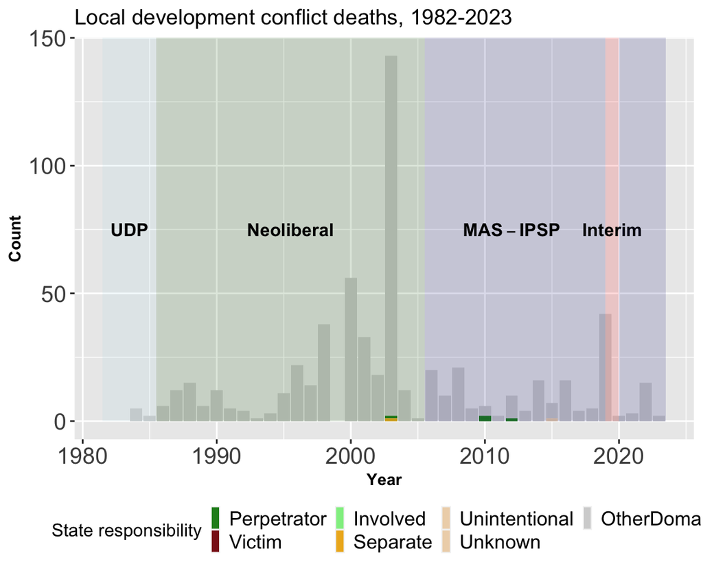

### Map of deaths by municipality

[interactive chart not shown]

### Event Table

| Event | Year | Confirmed | State Perp | State Victim | Sep from State | Protest Domain | President |
| --- | --- | --- | --- | --- | --- | --- | --- |
| Caranavi blockade clash | 2003-01-30 | 1 | 0 | 0 | 1 | Local development | Gonzalo Sanchez de Lozada (2nd) |
| Santa Rosa del Sara protests | 2003-07-22 | 1 | 1 | 0 | 0 | Local development | Gonzalo Sanchez de Lozada (2nd) |
| Caranavi development blockade | 2010-05-11 | 2 | 2 | 0 | 0 | Local development | Evo Morales |
| Caranda gas plant occupation | 2012-07-31 | 1 | 1 | 0 | 0 | Local development | Evo Morales |
| Potosi blockade hypotheremia death | 2015-07-27 | 1 | 0 | 0 | 0 | Local development | Evo Morales |